# Your Digest for Thursday, Sep 28, 2023 11:59 PM

#2021SBR-JUL/Q01  
#2021SBR-JUL/Q03  
#2021SBR-JUL/Q13  
#2021SBR-JUL/Q13

# Brown sequard syndrome

#2021SBR-JULQ19

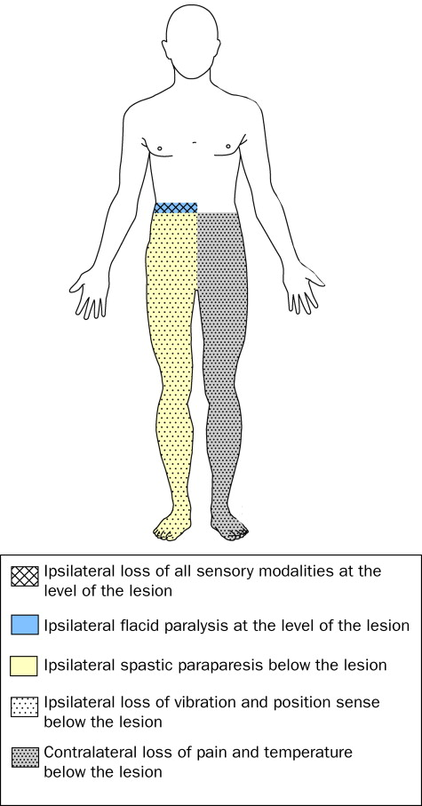

# Brucellosis

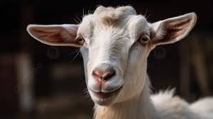

Obligate intracellular bacterium - *Brucella*  
Spread by drinking raw milk from infected goats / cattle or through respiratory tract.  
Bacterium disseminates via lymphatics -> blood -> reticuloendothelial system.  
1 - 3 week incubation period.  
Insidious onset of headache, malaise, weakness and fever.  
#lymphadeonpathy and #hepatosplenomegaly are common.  
Sacroilitis, osteomyelitis, infective endocarditis, epididymoorchitis, meningoencephalitis.  
Untreated, it can lead to chronic infection.  
Erythema nodosum like eruptions can occur.  
Long involvement with bronchitis and pneumonia can occur.  
Treatment: Antibiotices like doxycyline and rifampicin (which are active intracellulary) are used in combination rathern than monotherapy to prevent replapse.

# Erythematous rashes

Erythema marginatum : Rheumatic fever:

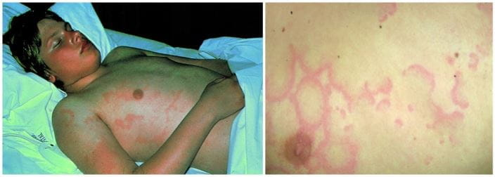

Erythema multiforme: Type IV hypersentivity reaction to infections agents or drugs. HSV is commonly implicated.

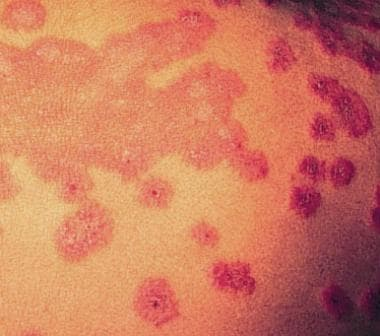

# Types of sytolic murmurs

Pan-systolic - ventricle leaks to a lower chamber or vessels - MR, TR, VSD  
Mid systolic: Crescendo - Decrescendo murmur - HOCM, AS, PS  
Late sysolic - mitral valve prolapse.

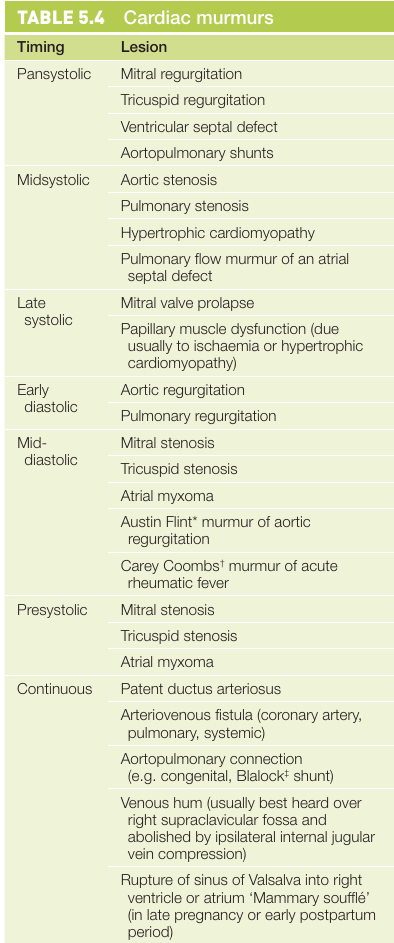

# Types of diastolic murmues

Early diastolic decrescendo - AR, PR  
Mid diastolic - MS, TS,

# Right Bundle branch block

#2021SBR-JUL/Q26

> The murmur and the gradient across the LVOT will **decrease with an increase in preload** (Squatting) or an *increase in afterload* (handgrip). In addition, the gradient and the murmur will increase with a decrease in preload (Valsalva maneuver, diuretics, standing). Certain maneuvers can affect murmurs auscultated in HOCM.

> "The HOCM murmur is **louder when the ventricular volume is low**, as the outflow tract is narrower".

> The murmur is a **high-pitched, crescendo-decrescendo, mid-systolic murmur usually heard best at the left lower sternal border**; it typically ends before the second heart sound. The murmur of oHCM does not radiate to the carotids like that of aortic stenosis (AS), *but may radiate to the base and apex of the heart*.

Over **days to weeks** the brain tissue compensates for reduced extracellular tonicity by *extruding solutes*.  
#2021SBR-JUL/Q15

> - If even even mild symptoms are present, **100ml bolus of 3% NaCl** is given and repeated as needed (maximum 3 boluses) to raise Na by 4-6 mEq / L in the first few hours hour.

> **Risk factors for ODS:**  
> *Patients with hypokalemia*, *female gender*, or history of *alcoholism* or liver transplant, Na < 105, malnourishment, concurrent liver disease.

Treatment is based on the level of hyponatremia:

1. Mild (Na > 130) - no need to 3% NaCl)
2. Moderate to severe (Na < 130)
   1. Severe symptoms - 3% NaCl 100 ml bolus
   2. Mild to moderate symptoms
      1. 120 - 129 - no need for hypertonic saline

[output not shown]

> [!INFO] Definition of DKA

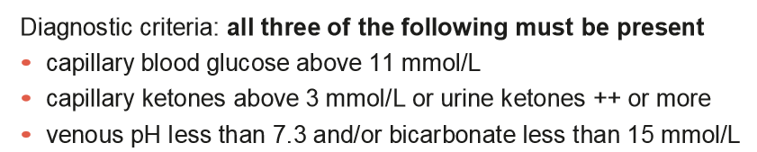

> **pH can be normal while still statisfying criteria for DKA**.
- **Two proposed reasons for observing lower glucose levels in DKA**
  - Patients with *DKA present earlier with symptoms*. Symptoms of hyperosmolarity tend to present later. (so there's more time for hyperglycemia to develop)
  - Patients with *DKA are younger* and usually present early in the development of Diabetes. Young patients, and those with early diabetes have **elevated** GFR. Therefore, DKA patients usually have high GFR which causes a lot of glucose to be lost via the urine -> this limits serum glucose concentration.

## Management of DKA And HSS

#2021SBR-JUL/Q14

> [!INFO]  
> For DKA, expected target is resolution of ketonaemia and acidosis in **24 hours**.

Replace total fluid deficit in 24 hours

###### Initial hour

[output not shown]

###### 60 minutes to 6 hours

- Target a rate of fall of ketons of 0.5 mmol/L/hr or rise of HCO3 of 3mmol/L/hr.
- Blood glucose fall of 3mmol / L / hr (54 mg/dL / Hr)
- If blood flucose falls below 14mmol/L (252 mg/Ld) add 10% dextrose 125 ml/hr.  
  Patients have a **total potassium deficit** (due to vomiting and diuresis) but it is **masked** by shift of KCl from ICF to ECF. Insulin administration will unmask the deficit and cause rapid fall of serum K+ as K+ shifts back into cells.
- The addition of K+ is likely required with the second litre of fluid.
- Potassium replacement doses:

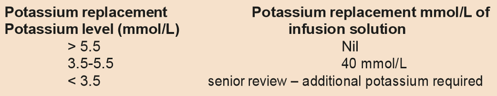

  - **Start potassium infusion even when K+ level is within normal**

**When to titrate dose:**

- If not meeting the targets [[#60 minutes to 6 hours|above]] above for **rate of resolution**
- Can reduce dose to 0.05u/Kg/hr in patient becomes hypoglycaemic.

**When to stop:**  
Until ketones < 0.6 mmol/L OR venous pH > 7.3 OR venous bicarb > 18 mmol/L.

##### Place for bicarbonate infusion

Use of bicarbonate is controversial. Some studies suggest it may impair renal ketone clearance and paradoxically worsen ketosis.  
Few indications for bicarbonate infusion:

- pH < 6.9
- life threatening hyperkalemia because HCO3 will drive K+ into cells.

##### Criteria for Severe DKA

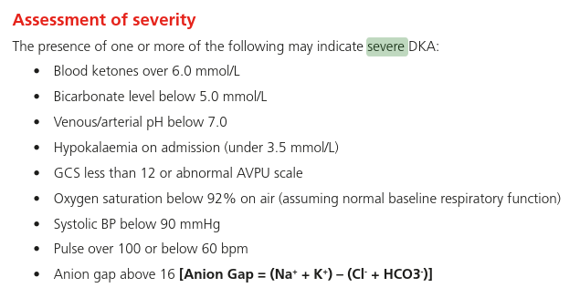

#2021GM-JUL/Q25

[output not shown]

> Activation of the *classical pathway* will typically result in lowering of *both C3 and C4*, and therefore disorders in which BOTH C3 and C4 (but in *these, C4 drops more than C3*) are decreased include *lupus nephritis* and *cryoglobulinemia*: [Source](https://www.renalfellow.org/2009/11/09/complement-levels-glomerulonephritis/) <- blog post; verified here [Source](https://academic.oup.com/ndt/article/20/12/2613/1924771)

> [!INFO] Vascular demential / parkinsons  
> #2021SBR-JULQ7  
> **Vascular parkinsonism** differs from Parkinson disease and other Lewy body diseases in that *bradykinesia affects the legs more than the arms* ("lower-body parkinsonism") and, in contrast to Parkinson disease, *there is no resting tremor*.  
> #2021SBR-JULQ23  
> #2021GM-JUL/Q27

Summary: Commonset neuromuscular junction disorder. Starts with eye symptoms. Can lead to myasthenic crisis. This can be precipitated by infections.

Commoner in females.

- Affects limbs as well. - **proximal weakness** (distal predominant weakness is rare), often asymmetrical.
- Presents as paraneoplastic syndrome of thymoma.  
  May require prolonged ventilation.

**Commonest Type** of of Motor neuron disease

> ipsilateral Cerebellar Signs

#2021GM-JUL/Q31

#2021GM-JUL/Q24

EKG changes can include increased amplitude and width of P wave, T wave flattening and inversion, **prominent U waves** and apparent long QT intervals due to merging of the T and U wave and 'mild' ST depression.  
The U-wave is a deflection following the T wave. . Potassium levels that are critically low (<1.7 mmol/L) can lead to torsades de pointes or“twisting of the points”, a polymorphic ventricular tachycardia.

- They are Granulomatous diseasesi

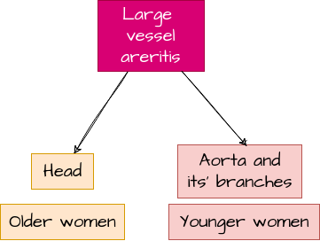

Patient it always > 50 years old; sudden *onset pain and stiffness* (**but not weakness**) of *limb girdles* / proximal muscles, associated with raised inflammatory markers.  
**Treatment:** 15mg prednisilone mane : improvement is significant in 24 to 48 hours.  
#2022SBR Q8  
#2021GM-JUL/Q17

> [!INFO] The most common idiopathic systemic vasculitis.  
> Females >>> males (3:1)  
> Always over 50;  
> Commonest in scandinavians.

[figure not shown]

- Inflammatory, *granulomatous*, arteritis or large **cerebral arteries**.
- **Histology:** Cellular infiltrates of CD4+ cells, macrophages and giant cells.
- Patient has usually had **past or current PMR**. (age always > 50)
- **Presentations:** Severe headaches, scalp / temple tenderness.
- **IX:** NCNC anaemia and elevated ESR.
- Treatment should commence immediately.
- Giving **steroids is essential**, since it can prevent vision loss due to ophthalmic artery ischemia.
- **Steroid should be given in much higher doses than PMR**.
- High dose steroid therapy can cause osteoporosis.
- Definitive Dx : temporal artery biopsy. Patchy lesions -> >1cm needs to be examined.
- Only half will have [[Miscellaneous respiratory medicine#Polymyalgia rheumatica|polymyalgia rheumatica]]
- Almost **never** occurs in young people (below 50 years old)
- Liver biochemistry may be abnormal  
  AKA pulseless disease or aortic arch syndrome.

> [!INFO]  
> Complete obstruction of the left common carotid

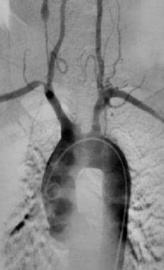

> (eg, bruit, especially carotid; blood pressure difference of extremities, difference in pulse volume, claudication, hypertension)  
> Steroids are the mainstay.  
> Diagnosis: MR angiograms.  
> Post prandial abdominal pain, diarrhoea, GI haemorrhage.
4. Renal: **haematuria and proteinuria**.